# Homework 3

Joseph Segich

2/26/2022

Read in the penguin data

```r
library (readr)

urlfile="https://raw.githubusercontent.com/jsegich/STA553/main/data/w02-penguins%20(1).csv"

penguin<-read_csv(url(urlfile))

str(penguin)
```

```
## spec_tbl_df [344 × 9] (S3: spec_tbl_df/tbl_df/tbl/data.frame)
##  $ X1               : num [1:344] 1 2 3 4 5 6 7 8 9 10 ...
##  $ species          : chr [1:344] "Adelie" "Adelie" "Adelie" "Adelie" ...
##  $ island           : chr [1:344] "Torgersen" "Torgersen" "Torgersen" "Torgersen" ...
##  $ bill_length_mm   : num [1:344] 39.1 39.5 40.3 NA 36.7 39.3 38.9 39.2 34.1 42 ...
##  $ bill_depth_mm    : num [1:344] 18.7 17.4 18 NA 19.3 20.6 17.8 19.6 18.1 20.2 ...
##  $ flipper_length_mm: num [1:344] 181 186 195 NA 193 190 181 195 193 190 ...
##  $ body_mass_g      : num [1:344] 3750 3800 3250 NA 3450 ...
##  $ sex              : chr [1:344] "male" "female" "female" NA ...
##  $ year             : num [1:344] 2007 2007 2007 2007 2007 ...
##  - attr(*, "spec")=
##   .. cols(
##   ..   X1 = col_double(),
##   ..   species = col_character(),
##   ..   island = col_character(),
##   ..   bill_length_mm = col_double(),
##   ..   bill_depth_mm = col_double(),
##   ..   flipper_length_mm = col_double(),
##   ..   body_mass_g = col_double(),
##   ..   sex = col_character(),
##   ..   year = col_double()
##   .. )
```

##Refine the Scatterplot

Here we make the following updates:

Change the color to cyan, orange, blue so that color palette is categorical

Slightly modify the size of the points for readability

Modify the shape of the points to enhance ability to dicern size differences

Increase the font on the note indicating size is proportional to body mass in grams

Remove the penguin picture as this adds little to the overall chart

Change the title so that it gives context to the information displayed

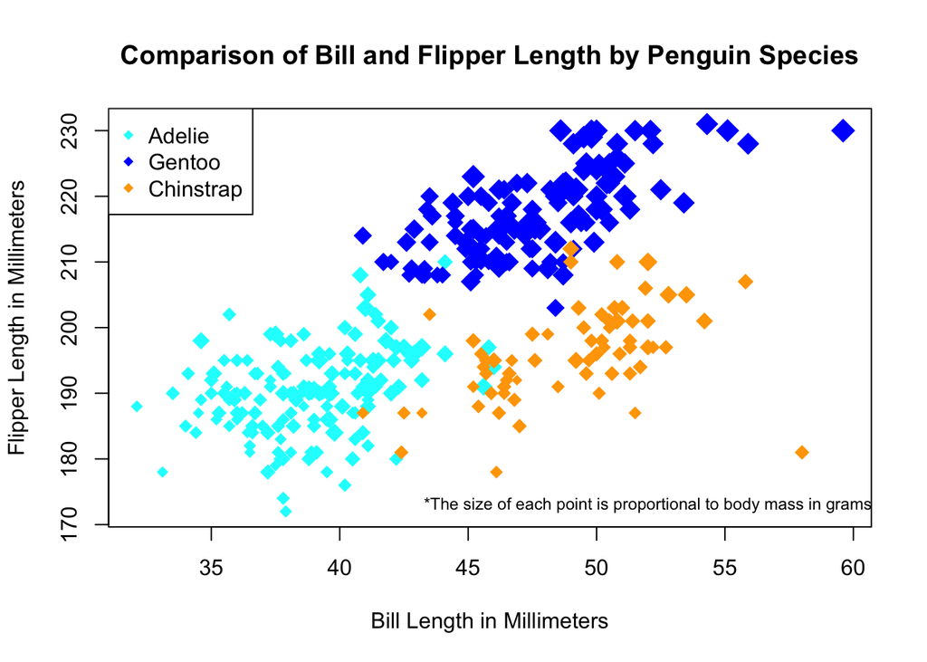

```r
Bill_length=penguin$bill_length_mm
Flipper_length=penguin$flipper_length_mm
species=penguin$species
peng_size=(penguin$body_mass_g/2500)

## identifying the species
Adelie.id = which(species=="Adelie")  # value are case sensitive!
Gentoo.id = which(species=="Gentoo")
Chinstrap.id = which(species=="Chinstrap")

## making an empty plot: type = "n" ==> no point
plot(Bill_length,Flipper_length,xlab = ("Bill Length in Millimeters"), ylab = ("Flipper Length in Millimeters"), main = "Comparison of Bill and Flipper Length by Penguin Species", type = "n")

points(Bill_length[Adelie.id], Flipper_length[Adelie.id], pch = 18, col = "cyan", cex=peng_size[Adelie.id])
points(Bill_length[Gentoo.id], Flipper_length[Gentoo.id], pch = 18, col = "blue", cex=peng_size[Gentoo.id])
points(Bill_length[Chinstrap.id], Flipper_length[Chinstrap.id], pch =18, col = "orange", cex=peng_size[Chinstrap.id])
legend("topleft", c( "Adelie", "Gentoo", "Chinstrap"),
                  col=c("cyan", "blue", "orange"),
                  pch=c(18, 18, 18))

text(52, 173, "*The size of each point is proportional to body mass in grams", col = "black", cex = 0.75)
```

##Subset the penguin data

```r
##Omit Missing Values

penguin<-na.omit(penguin)

##Subset as requested

penguin<- subset(penguin, (penguin$species == ("Adelie") | penguin$species == ("Gentoo")) & (3500<body_mass_g) & (body_mass_g<5000) & (penguin$island == ("Torgersen") | penguin$island == ("Biscoe")) , select=c(X1:year))

##Add a BMI Variable

penguin <- mutate(penguin,BMI=body_mass_g/4000)

##Remove the following variables from our Final set

penguin <- select(penguin,-c(X1,sex,year,body_mass_g))
```

##Remake the original scatterplot with this subset

[figure not shown]

```r
Bill_length=penguin$bill_length_mm
Flipper_length=penguin$flipper_length_mm
species=penguin$species
peng_size=(penguin$BMI*1.8)

## identifying the species
Adelie.id = which(species=="Adelie")  # value are case sensitive!
Gentoo.id = which(species=="Gentoo")

## making an empty plot: type = "n" ==> no point
plot(Bill_length,Flipper_length,xlab = ("Bill Length in Millimeters"), ylab = ("Flipper Length in Millimeters"), main = "Bill length vs Flipper length", type = "n")

points(Bill_length[Adelie.id], Flipper_length[Adelie.id], pch = 20, col = "red", cex=peng_size[Adelie.id])
points(Bill_length[Gentoo.id], Flipper_length[Gentoo.id], pch = 20, col = "blue", cex=peng_size[Gentoo.id])

legend("topleft", c("Adelie", "Gentoo"),
                  col=c("red", "blue"),
                  pch=c(20, 20, 20, 20))

library(jpeg)
library(RCurl)

peng.img <- "https://raw.githubusercontent.com/jsegich/STA553/main/data/Peng_Picture.jpeg"
my_peng <- readJPEG(getURLContent(peng.img))
raster.peng <- as.raster(my_peng)

rasterImage(raster.peng,48,185,50,195)
text(46, 181, "*The size is proportional to body mass in grams", col = "black", cex = 0.5)
```

##Paragraph comparing the relationship between the two variables across the species.

Based on the data we can see that Gentoo penguins from Torgersen and Biscoe with body mass between 3,500g and 5,000g tend to have both larger flipper length and larger bill length than Adelie penguins meeting the same criteria. We can also see that there appears to be more variation in the bill length of Adelie penguins than Gentoo penguins. The variation in flipper length seems to be about the same, with Adlei having perhaps slightly more variation. There are a few outliers, most notably the penguin at 44 x, 210 y with the largest flipper length and 4th largest bill length. This penguinn may warrant further investigation

Read in the life expectancy data from section 12

```r
library (readr)

urlfile1="https://raw.githubusercontent.com/jsegich/STA553/main/data/income_per_person.csv"

urlfile2="https://raw.githubusercontent.com/jsegich/STA553/main/data/life_expectancy_years.csv"

urlfile3="https://raw.githubusercontent.com/jsegich/STA553/main/data/population_total.csv"

urlfile4="https://raw.githubusercontent.com/jsegich/STA553/main/data/countries_total.csv"

income_per_person<-read_csv(url(urlfile1))

life_expectancy_years<-read_csv(url(urlfile2))

population_total<-read_csv(url(urlfile3))

countries_total<-read_csv(url(urlfile4))
```

##Prepare a single data set based on data set 12

```r
income_per_person_fin <- income_per_person %>%
  gather(key = "Year",       # the column names of the wide table
         value = "Income",  # the numerical values of the table
         - geo,          # drop country variable: its value will not be gathered (stacked)!
         na.rm = FALSE)       # removing records with missing values

life_expectancy_years_fin <- life_expectancy_years %>%
  gather(key = "Year",       # the column names of the wide table
         value = "Life Expectancy",  # the numerical values of the table
         - geo,          # drop country variable: its value will not be gathered (stacked)!
         na.rm = FALSE)       # removing records with missing values

LifeExpIncom <- full_join(life_expectancy_years_fin,income_per_person_fin)

LifeExpIncom <- LifeExpIncom  %>%
                      mutate(year = substr(Year,1,5)) %>%
                      select(-Year)

innerjoin = merge(x = LifeExpIncom, y = countries_total, by.x = 'geo', by.y ='name', all = TRUE)

##Final data set

Final_Set <- full_join(LifeExpIncom,innerjoin)

##Check out the values

head(Final_Set)
```

```
## # A tibble: 6 x 14
##   geo           `Life Expectanc… Income year  `alpha-2` `alpha-3` `country-code`
##   <chr>                    <dbl>  <dbl> <chr> <chr>     <chr>              <dbl>
## 1 Afghanistan               28.2    603 1800  AF        AFG                    4
## 2 Albania                   35.4    667 1800  AL        ALB                    8
## 3 Algeria                   28.8    715 1800  DZ        DZA                   12
## 4 Andorra                   NA     1200 1800  AD        AND                   20
## 5 Angola                    27      618 1800  AO        AGO                   24
## 6 Antigua and …             33.5    757 1800  AG        ATG                   28
## # … with 7 more variables: iso_3166-2 <chr>, region <chr>, sub-region <chr>,
## #   intermediate-region <chr>, region-code <dbl>, sub-region-code <dbl>,
## #   intermediate-region-code <dbl>
```